# Random Variables

Distributions, Transformations, Moments, and Limit Theorems

## What Is a Random Variable?

**Definition — Probability Space**

A **probability space** is a triple $(\Omega, \mathcal{F}, P)$ where

- $\Omega$ is the sample space
- $\mathcal{F}$ is a $\sigma$-algebra on $\Omega$
- $P: \mathcal{F} \to [0,1]$ is a probability measure

**Definition — Random Variable**

A **random variable** $X$ is a function that maps outcomes from a sample space $\Omega$ to real numbers:
$$X: \Omega \rightarrow \mathbb{R}$$

**Key Insight**

Random variables let us work with **numerical quantities** in probability theory — arithmetic, averages and calculus become available.

## Random Variable Example

**Example:** tossing two coins.

- Sample space: $\Omega = \{HH, HT, TH, TT\}$
- Let $X$ = number of heads
- $X(HH) = 2$
- $X(HT) = X(TH) = 1$
- $X(TT) = 0$

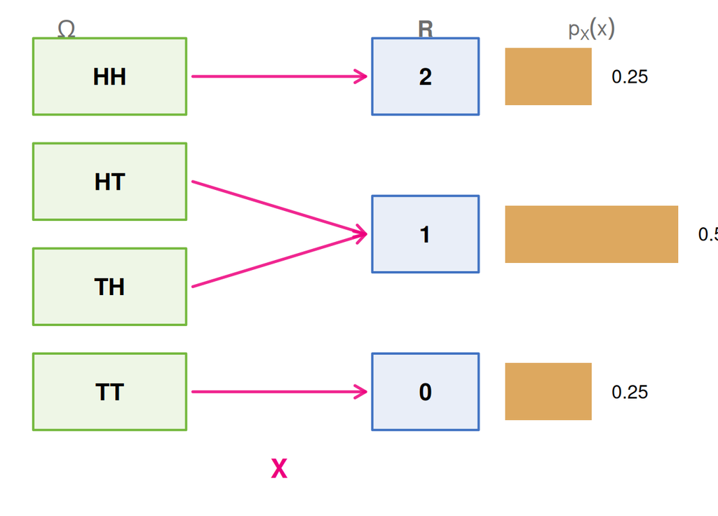

## The Distribution Zoo, Live

Move the cut-off $x_0$ and watch the **shaded area** on top become the **height** of the CDF below.

[interactive chart not shown]

## Cumulative Distribution Function (CDF)

**Definition — CDF**

The **cumulative distribution function** of a random variable $X$ is
$$F_X(x) = P(X \leq x) \quad \text{for } x \in \mathbb{R}$$

**Properties of the CDF:**

1. $0 \leq F_X(x) \leq 1$
2. $F_X$ is non-decreasing
3. $F_X$ is right-continuous: $\lim_{h \to 0^+} F_X(x+h) = F_X(x)$

**Why the CDF matters**

It is the one object that exists for **every** random variable — discrete, continuous, or a mixture of both. PMFs and PDFs are what the CDF looks like in two special cases.

# Types of Random Variables

## Discrete Random Variables

**Definition — Discrete Random Variable**

A random variable $X$ is **discrete** if it takes values in a countable set $\{x_1, x_2, x_3, \ldots\}$.

**Probability Mass Function (PMF):**
$$p_X(x) = P(X = x)$$

**Properties:**

1. $p_X(x) \geq 0$ for all $x$
2. $\sum_{x} p_X(x) = 1$
3. $P(X \in A) = \sum_{x \in A} p_X(x)$

## Continuous Random Variables

**Definition — Continuous Random Variable**

A random variable $X$ is **continuous** if there exists a non-negative function $f_X$ such that
$$P(a \leq X \leq b) = \int_a^b f_X(x)\, dx$$

**Probability Density Function (PDF):**
$$f_X(x)=\frac{d}{dx}P(X\leq x)$$

**Properties:**

1. $f_X(x) \geq 0$ for all $x$
2. $\int_{-\infty}^{\infty} f_X(x)\, dx = 1$
3. $P(X = x) = 0$ for any single point $x$

## Relationship Between CDF and PMF/PDF

**Discrete case:**
$$F_X(x) = \sum_{t \leq x} p_X(t)$$
$$p_X(x) = F_X(x) - F_X(x^-)$$

The CDF is a **staircase**; the jump heights *are* the probabilities.

**Continuous case:**
$$F_X(x) = \int_{-\infty}^x f_X(t)\, dt$$
$$f_X(x) = \frac{d}{dx} F_X(x)$$

The CDF is **smooth**; the density is its slope.

[interactive chart not shown]

# Common Distributions

## Bernoulli Distribution

**Definition:** models a single trial with two outcomes.

**PMF:**
$$p_X(x) = \begin{cases} p & \text{if } x = 1 \\ 1-p & \text{if } x = 0 \\ 0 & \text{otherwise} \end{cases}$$

**Parameters:** $p \in [0,1]$ (probability of success)

**Moments:** $E[X] = p$, $\text{Var}(X) = p(1-p)$

**Notation:** $X \sim \text{Bernoulli}(p)$

## Binomial Distribution

**Definition:** number of successes in $n$ independent Bernoulli trials.

**PMF:**
$$p_X(k) = \binom{n}{k} p^k (1-p)^{n-k}, \quad k = 0, 1, \ldots, n$$

**Parameters:**

- $n \in \mathbb{N}$ (number of trials)
- $p \in [0,1]$ (probability of success)

**Moments:**

- $E[X] = np$
- $\text{Var}(X) = np(1-p)$

**Notation:** $X \sim \text{Binomial}(n, p)$

## Poisson Distribution

**Definition:** models rare events or counts in a fixed interval.

**PMF:**
$$p_X(k) = \frac{\lambda^k e^{-\lambda}}{k!}, \quad k = 0, 1, 2, \ldots$$

**Parameter:** $\lambda > 0$ (rate)

**Moments:** $E[X] = \lambda$, $\text{Var}(X) = \lambda$

**Key Property**

Poisson approximates the Binomial when $n$ is large, $p$ is small, and $np = \lambda$ is moderate.

**Notation:** $X \sim \text{Poisson}(\lambda)$

## Uniform Distribution

**Definition:** equal likelihood over an interval $[a, b]$.

**PDF:**
$$f_X(x) = \begin{cases} \frac{1}{b-a} & \text{if } a \leq x \leq b \\ 0 & \text{otherwise} \end{cases}$$

**Moments:** $E[X] = \frac{a+b}{2}$, $\text{Var}(X) = \frac{(b-a)^2}{12}$

**CDF:**
$$F_X(x) = \begin{cases} 0 & \text{if } x < a \\ \frac{x-a}{b-a} & \text{if } a \leq x \leq b \\ 1 & \text{if } x > b \end{cases}$$

**Notation:** $X \sim \text{Uniform}(a, b)$

## Exponential Distribution

**Definition:** models waiting times between events.

**PDF:**
$$f_X(x) = \lambda e^{-\lambda x}, \quad x \geq 0$$

**CDF:**
$$F_X(x) = 1 - e^{-\lambda x}, \quad x \geq 0$$

**Parameter:** $\lambda > 0$ (rate)

**Moments:** $E[X] = \frac{1}{\lambda}$, $\text{Var}(X) = \frac{1}{\lambda^2}$

**Memoryless Property**

$$P(X > s + t \mid X > s) = P(X > t)$$
A used component is as good as new — the only continuous distribution with this property.

**Notation:** $X \sim \text{Exp}(\lambda)$

## Normal Distribution

**Definition:** the most important continuous distribution.

**PDF:**
$$f_X(x) = \frac{1}{\sigma\sqrt{2\pi}} \exp\left(-\frac{(x-\mu)^2}{2\sigma^2}\right)$$

**Parameters:**

- $\mu \in \mathbb{R}$ (mean)
- $\sigma^2 > 0$ (variance)

**Moments:** $E[X] = \mu$, $\text{Var}(X) = \sigma^2$

**Standard Normal:** $Z \sim N(0,1)$, CDF written $\Phi(z)$

**Notation:** $X \sim N(\mu, \sigma^2)$

## Binomial → Poisson, Live

Hold $\lambda = np$ fixed and let $n$ grow: the binomial mass collapses onto the Poisson.

[interactive chart not shown]

Watch the largest gap in the readout — it shrinks roughly like $\lambda^2/n$.

[interactive chart not shown]

# Transformations of Random Variables

## Functions of Random Variables

**Question:** if $Y = g(X)$, how do we find the distribution of $Y$?

**Discrete case:**
$$p_Y(y) = \sum_{x:\, g(x) = y} p_X(x)$$

**Continuous case (monotonic** $g$): if $g$ is strictly monotonic with inverse $g^{-1}$,
$$f_Y(y) = f_X(g^{-1}(y)) \left|\frac{d}{dy}g^{-1}(y)\right|$$

**Where the Jacobian comes from**

Densities are probability *per unit length*. Stretching the axis by $g$ dilutes the density; the derivative term is the bookkeeping that keeps the total area at 1.

## Linear Transformations

**If** $Y = aX + b$:

**Expected value:**
$$E[Y] = aE[X] + b$$

**Variance:**
$$\text{Var}(Y) = a^2\text{Var}(X)$$

**Special Case — Standardisation**

$$Z = \frac{X - E[X]}{\sqrt{\text{Var}(X)}}$$
Then $E[Z] = 0$ and $\text{Var}(Z) = 1$.

Note what standardisation does **not** do: it moves and rescales, but it never changes the *shape*. A skewed $X$ gives a skewed $Z$.

## Example: Square of a Standard Normal

Let $X \sim N(0,1)$ and $Y = X^2$. Find the distribution of $Y$.

**Solution.** For $y > 0$:
$$\begin{aligned} F_Y(y) &= P(Y \leq y) = P(X^2 \leq y) \\ &= P(-\sqrt{y} \leq X \leq \sqrt{y}) \\ &= \Phi(\sqrt{y}) - \Phi(-\sqrt{y}) \end{aligned}$$

Taking the derivative:
$$f_Y(y) = \frac{1}{\sqrt{2\pi y}} e^{-y/2}, \quad y > 0$$

**Recognise it**

This is the **Chi-squared distribution with 1 degree of freedom** — and note $g$ was *not* monotonic, which is why two branches had to be added up.

## Transformations, Live

Left: the distribution of $X$. Right: what $g$ does to it.

[interactive chart not shown]

# Moments

## Expected Value

**Definition — Expected Value**

The **expected value** (or mean) of a random variable $X$ is

**Discrete:** $\displaystyle E[X] = \sum_{x} x \cdot p_X(x)$ **Continuous:** $\displaystyle E[X] = \int_{-\infty}^{\infty} x \cdot f_X(x)\, dx$

**Properties:**

- Linearity: $E[aX + bY] = aE[X] + bE[Y]$
- If $X \geq 0$, then $E[X] \geq 0$
- $E[c] = c$ for any constant $c$

**Intuition**

$E[X]$ is the **balance point** of the distribution: put the density on a seesaw, and this is where it tips level.

## Variance and Standard Deviation

**Definition — Variance**

$$\text{Var}(X) = E[(X - E[X])^2] = E[X^2] - (E[X])^2$$

**Definition — Standard Deviation**

$$\sigma_X = \sqrt{\text{Var}(X)}$$

**Properties:**

- $\text{Var}(X) \geq 0$
- $\text{Var}(aX + b) = a^2 \text{Var}(X)$ — shifting does nothing, scaling squares
- If $X$ and $Y$ are independent: $\text{Var}(X + Y) = \text{Var}(X) + \text{Var}(Y)$

## More Generally: Moments

**Definition — Raw and Central Moments**

The $k$-th raw moment is $\mu_k' = E[X^k]$.

The $k$-th central moment is $\mu_k = E[(X - E[X])^k]$.

**Important special cases:**

- $\mu_1' = E[X]$ — the mean
- $\mu_2 = \text{Var}(X)$ — the variance
- $\mu_3$ measures **skewness**: $\gamma_1 = \dfrac{\mu_3}{\sigma^3}$
- $\mu_4$ measures **kurtosis**: $\gamma_2 = \dfrac{\mu_4}{\sigma^4} - 3$ (excess kurtosis)

## Moments, Live

Two knobs, four numbers. Watch which moments react to which knob.

[interactive chart not shown]

$X = \sinh\!\big((\sinh^{-1} Z + \varepsilon)/\delta\big)$ with $Z \sim N(0,1)$, standardised to mean 0, variance 1. At $\varepsilon = 0, \delta = 1$ it *is* the normal.

[interactive chart not shown]

## What the Knobs Do

- The **skew knob** moves mass to one side: $\gamma_1$ changes sign, while the mean and variance stay pinned at 0 and 1 by construction.
- The **tail knob** trades shoulder for tail: $\delta < 1$ gives heavy tails (large $\gamma_2$), $\delta > 1$ gives light ones.
- Mean and variance alone therefore say **nothing** about shape — two distributions can match on both and still look completely different.

**Takeaway**

Higher moments are how we describe the part of a distribution that $\mu$ and $\sigma^2$ cannot see.

# Limit Theorems

## Laws of Large Numbers

**Theorem — Law of Large Numbers**

Let $X_1, X_2, \ldots$ be i.i.d. with $E[|X_i|] < \infty$ and $E[X_i] = \mu$. Then

1. for $\bar{X}_n = \frac{1}{n}\sum_{i=1}^n X_i$ and any fixed $\epsilon > 0$:
   $$\lim_{n \to \infty} P\left(\left|\bar{X}_n - \mu\right| > \epsilon\right) = 0 \qquad \text{(WLLN)}$$
2. $$P\left(\lim_{n \to \infty} \bar{X}_n = \mu\right) = 1 \qquad \text{(SLLN)}$$

**Key differences:**

- **WLLN:** convergence in probability ($\bar{X}_n \xrightarrow{P} \mu$)
- **SLLN:** almost sure convergence ($\bar{X}_n \xrightarrow{a.s.} \mu$)

## WLLN versus SLLN, Live

Both laws say $\bar{X}_n$ ends up inside the band $\mu \pm \varepsilon$. They differ in **what** has to become rare.

[interactive chart not shown]

200 paths of fair-coin tosses, $\mu = 0.5$.

**Weak:** the share of paths outside the band *at* $n$ goes to 0.

**Strong:** the share that will still leave the band *at some* $m \ge n$ goes to 0 — every path eventually stays inside for good.

The strong share counts more paths, so its curve is always on top. (“Later” looks ahead to $m$ = 50,000.)

[interactive chart not shown]

## The Law of Large Numbers, Live

Each line is one sequence of draws, plotted as the running average $\bar{X}_n$.

[interactive chart not shown]

## What the Paths Show

- Every path wanders at first, then tightens around $\mu$ — the spread of $\bar{X}_n$ shrinks like $1/\sqrt{n}$.
- The **Cauchy** case is the useful counterexample: the sample mean jumps around forever, because $E|X| = \infty$ and the theorem’s hypothesis fails.

**Read the assumptions**

“Averages converge” is not a law of nature. It is a theorem, and it has conditions.

## Central Limit Theorem

**Theorem — Central Limit Theorem**

Let $X_1, X_2, \ldots$ be i.i.d. with $E[X_i] = \mu$ and $\text{Var}(X_i) = \sigma^2 < \infty$. Then
$$\frac{\bar{X}_n - \mu}{\sigma/\sqrt{n}} \xrightarrow{\ d\ } N(0,1)$$
as $n \to \infty$.

**Practical interpretation:** for large $n$, $\bar{X}_n$ is approximately normal,
$$\bar{X}_n \approx N\left(\mu, \frac{\sigma^2}{n}\right)$$

**Rule of thumb:** $n \geq 30$ is often sufficient — but the *Any Population* demo two slides on shows how badly that can fail.

## The Central Limit Theorem, Live

Average $n$ independent $\text{Uniform}(0,1)$ draws. No simulation: each extra term is one more **convolution**, so this is the exact density.

[interactive chart not shown]

$Z = \dfrac{\bar{X}_n - a_n}{b_n}$, where $\bar{X}_n = \frac{1}{n}(X_1 + \cdots + X_n)$.

Only $a_n = \mu$ together with $b_n = \sigma/\sqrt{n}$ gives the standard normal. The frame never moves: a wrong $a_n$ walks the density off the edge, too small a $b_n$ flattens it, too large a $b_n$ collapses it to a spike.

[interactive chart not shown]

## Any Population, Live

The population on the left can be as ugly as you like. Watch the right-hand panel anyway.

[interactive chart not shown]

## What the CLT Demo Teaches

- At $n = 1$ the right panel *is* the population — standardised, but the same shape.
- Skewness of the standardised mean falls like $\gamma_1/\sqrt{n}$: it fades, but slowly.
- **Bernoulli(0.08)** at $n = 30$ is still visibly lumpy and skewed — the “$n \geq 30$” rule of thumb quietly assumes the population is not too extreme.

**Takeaway**

The CLT is a statement about the **limit**. How large $n$ must be before the approximation is usable depends on the population’s shape, not on a magic number.

# Summary

## Key Takeaways

1. **Random variables** map outcomes to numbers, enabling mathematical analysis of uncertainty
2. **Discrete vs continuous:** different tools (PMF vs PDF) but unified by the CDF
3. **Common distributions** model different real-world phenomena, and are related to one another (Binomial → Poisson, $N(0,1)^2 \to \chi^2_1$)
4. **Transformations** let us derive new distributions from known ones
5. **Expected value and variance** characterise the centre and spread — and higher moments the shape
6. **Limit theorems** describe the behaviour of averages: the LLN says *where* $\bar{X}_n$ goes, the CLT says *how it is spread out* on the way there

## Next: Multivariate Random Variables

**Two or more at a time**

- Joint, marginal and conditional distributions
- Independence
- Covariance and correlation

**And then**

- The multivariate normal
- Conditional expectation
- Sums and sampling distributions